# GoogleCapstoneMarkdown

Dillon O’Rourke

2022-03-15

## **Disclaimer**

This case study is a project for my online portfolio as part of the Google Data Analytics professional certificate and is entirely fictional.

# Introduction

I am a junior data analyst working on the marketing analyst team at [Bellabeat](https://bellabeat.com/), a high-tech manufacturer of health-focused products for women. Bellabeat is a successful small company, but they have the potential to become a larger player in the global smart device market. Urška Sršen, cofounder and Chief Creative Officer of Bellabeat, believes that analyzing smart device fitness data could help unlock new growth opportunities for the company.

### *The purpose of this project;*

Is to use data to gain insights into customer usage of the non-company products and identify new growth opportunities for the company.  
An analysis of smart device usage could identify trends which could be investigated further to explore if they can be applied to Bellabeat customers. Applying these trends and behaviors to the company’s marketing strategy could improve future sales revenue.

### *The key business tasks;*

- Analyse smart device data and gain insight into how consumers are using their devices.
  - What are some trends in smart device usage?
  - How could these trends apply to Bellabeat customers?
  - How could these trends help influence Bellabeat marketing strategy?
- Create a presentation of my analysis and high-level recommendations for how these trends can inform Bellabeat marketing strategy to the executive team.

### *Assumptions or theories*

### *Products*

- **Bellabeat app:** The Bellabeat app provides users with health data related to their activity, sleep, stress,menstrual cycle, and mindfulness habits. This data can help users better understand their current habits and make healthy decisions. The Bellabeat app connects to their line of smart wellness products.
- **Leaf:** Bellabeat’s classic wellness tracker can be worn as a bracelet, necklace, or clip. The Leaf tracker connects to the Bellabeat app to track activity, sleep, and stress.
- **Time:** This wellness watch combines the timeless look of a classic timepiece with smart technology to track user activity, sleep, and stress. The Time watch connects to the Bellabeat app to provide you with insights into your daily wellness.
- **Spring:** This is a water bottle that tracks daily water intake using smart technology to ensure that you are appropriately hydrated throughout the day. The Spring bottle connects to the Bellabeat app to track your hydration levels.
- **Bellabeat membership:** Bellabeat also offers a subscription-based membership program for users. Membership gives users 24/7 access to fully personalized guidance on nutrition, activity, sleep, health and beauty, and mindfulness based on their lifestyle and goals.

### *The Data*

1. [FitBit Fitness Tracker Data](https://www.kaggle.com/arashnic/fitbit).

Personal fitness tracker data collected from 30 consenting fitbit users in 2016. It includes minute level output for exercise, heart rate and daily activity.

- **Source:** External 3<sup>rd</sup> party data.
- **Type:** Structured continuous & discrete mostly nominal quantitative data.
- **Structure:** Time-series data for each individual user in several tables. Data ranges from daily to minute timestamps. Heartrate, calories, steps, sleep and weight information are provided by the data.

The daily data will be analysed first as it will provide the most high level view look for trends in daily data and then hourly or minute data can be delved into to provide a higher resolution view of a trend.

**Importing Packages**

```r
library(lubridate)
library(tidyverse)
library(ggplot2)
library(dplyr)
library(ggpubr)
```

**Importing the data**

```r
daily_activity <- read.csv('C:/Users/Dillon/Documents/Coding Learning/Google Data Analytics Course/Google Data Analytics Capstone Complete a Case Study/Data/Fitabase Data 3.12.16-4.11.16/dailyActivity_merged.csv')

sleepday <- read.csv('C:/Users/Dillon/Documents/Coding Learning/Google Data Analytics Course/Google Data Analytics Capstone Complete a Case Study/Data/Fitabase Data 3.12.16-4.11.16/SleepDay_merged.csv')
```

**Taking a look at the data;**

```r
tbl_day_act <- as_tibble(daily_activity)
tbl_day_act
```

```
## # A tibble: 940 x 15
##        Id ActivityDate TotalSteps TotalDistance TrackerDistance LoggedActivitie~
##     <dbl> <chr>             <int>         <dbl>           <dbl>            <dbl>
##  1 1.50e9 4/12/2016         13162          8.5             8.5                 0
##  2 1.50e9 4/13/2016         10735          6.97            6.97                0
##  3 1.50e9 4/14/2016         10460          6.74            6.74                0
##  4 1.50e9 4/15/2016          9762          6.28            6.28                0
##  5 1.50e9 4/16/2016         12669          8.16            8.16                0
##  6 1.50e9 4/17/2016          9705          6.48            6.48                0
##  7 1.50e9 4/18/2016         13019          8.59            8.59                0
##  8 1.50e9 4/19/2016         15506          9.88            9.88                0
##  9 1.50e9 4/20/2016         10544          6.68            6.68                0
## 10 1.50e9 4/21/2016          9819          6.34            6.34                0
## # ... with 930 more rows, and 9 more variables: VeryActiveDistance <dbl>,
## #   ModeratelyActiveDistance <dbl>, LightActiveDistance <dbl>,
## #   SedentaryActiveDistance <dbl>, VeryActiveMinutes <int>,
## #   FairlyActiveMinutes <int>, LightlyActiveMinutes <int>,
## #   SedentaryMinutes <int>, Calories <int>
```

```r
tbl_sleep <- as_tibble(sleepday)
tbl_sleep
```

```
## # A tibble: 413 x 5
##            Id SleepDay          TotalSleepRecor~ TotalMinutesAsl~ TotalTimeInBed
##         <dbl> <chr>                        <int>            <int>          <int>
##  1 1503960366 4/12/2016 12:00:~                1              327            346
##  2 1503960366 4/13/2016 12:00:~                2              384            407
##  3 1503960366 4/15/2016 12:00:~                1              412            442
##  4 1503960366 4/16/2016 12:00:~                2              340            367
##  5 1503960366 4/17/2016 12:00:~                1              700            712
##  6 1503960366 4/19/2016 12:00:~                1              304            320
##  7 1503960366 4/20/2016 12:00:~                1              360            377
##  8 1503960366 4/21/2016 12:00:~                1              325            364
##  9 1503960366 4/23/2016 12:00:~                1              361            384
## 10 1503960366 4/24/2016 12:00:~                1              430            449
## # ... with 403 more rows
```

# Data Cleaning & Filtering

**Renaming column names for readability.**

```r
tbl_day_act <- rename(tbl_day_act, ID = Id, Date = ActivityDate)
tbl_sleep <- rename(tbl_sleep, ID = Id, Datetime = SleepDay)
```

**Change Date & ID format** The format of column “ActivityDate” needs to be changed to a date format. Same with the sleep table

```r
tbl_day_act$Date <- mdy(tbl_day_act$Date)
tbl_day_act$ID <- as.character(tbl_day_act$ID)

tbl_sleep$Datetime<-gsub(" AM","",as.character(tbl_sleep$Datetime))
tbl_sleep$Datetime <- mdy_hms(tbl_sleep$Datetime)
tbl_sleep$ID <- as.character(tbl_sleep$ID)
```

**Check for duplicates** A return of 1 from the sum value after removal means there are none left not that there is 1. In the case of the sleep table, there are 4 rows that are duplicates, removing 3 leaves one 1.

```r
sum(duplicated(tbl_day_act), vars = TRUE)
```

```
## [1] 1
```

```r
tbl_day_act <- tbl_day_act[!duplicated(tbl_day_act), ]

sum(duplicated(tbl_sleep), vars = TRUE)
```

```
## [1] 4
```

```r
tbl_sleep <- tbl_sleep[!duplicated(tbl_sleep), ]
sum(duplicated(tbl_sleep), vars = TRUE)
```

```
## [1] 1
```

# Exploratory Analysis & Discussion

**Calculating the number of unique (distinct) user IDs in both tables.** The data source stated that 30 users supplied Fitbit tracker data. Therefore, Expectation = maximum value of 30

```r
n_distinct(tbl_day_act$ID)
```

```
## [1] 33
```

```r
n_distinct(tbl_sleep$ID)
```

```
## [1] 24
```

There are 33 user IDs in this table. *Cross-checking in excel:* using Data -> Remove Duplicates gave 33 for dailyActivity_merged.csv and 24 for the sleepDay_merged.csv table. The value of 33 could be users with multiple accounts, a second account created by a user during the timeframe that data was collected etc.

**Calculating the number of unique dates in the daily activity table** The data source stated that the data was collected between the 12th of April and the 12th of May. If the end date is included there should be 31 distinct dates. Creating a table of amount of days logged by each person(number of distinct dates for each ID)

```r
n_distinct(tbl_day_act$Date)
```

```
## [1] 31
```

```r
#number of distinct dates for each ID
data_days <- as_tibble(count_(unique(tbl_day_act), vars = 'ID'))
data_days
```

```
## # A tibble: 33 x 2
##    ID             n
##    <chr>      <int>
##  1 1503960366    31
##  2 1624580081    31
##  3 1644430081    30
##  4 1844505072    31
##  5 1927972279    31
##  6 2022484408    31
##  7 2026352035    31
##  8 2320127002    31
##  9 2347167796    18
## 10 2873212765    31
## # ... with 23 more rows
```

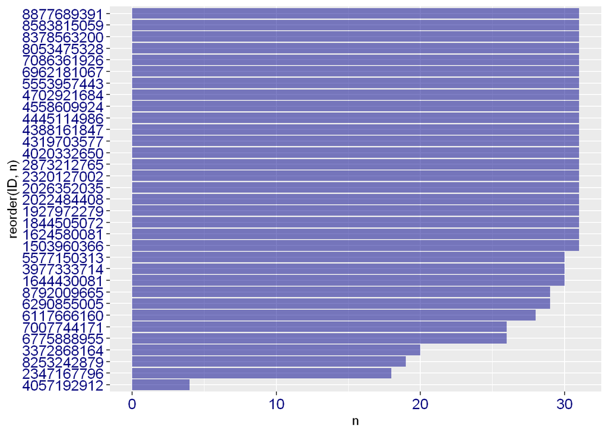

```r
ggplot(data = data_days, aes(x = reorder(ID, n), y = n)) +
  geom_bar(stat = 'identity', fill='blue4', alpha = 0.5) +
  theme(
  axis.text.x = element_text(color = "navyblue", size = 12, angle = 0),
  axis.text.y = element_text(color = "navyblue", size = 12, angle = 0)) +
  coord_flip()
```

**Summary statistics about each data frame** For the daily activity dataframe:

```r
data_days %>%
  select(n)%>%
  summary()
```

```
##        n
##  Min.   : 4.00
##  1st Qu.:29.00
##  Median :31.00
##  Mean   :28.48
##  3rd Qu.:31.00
##  Max.   :31.00
```

```r
tbl_day_act %>%
  select(TotalSteps,
         TotalDistance,
         SedentaryMinutes) %>%
  summary()
```

```
##    TotalSteps    TotalDistance    SedentaryMinutes
##  Min.   :    0   Min.   : 0.000   Min.   :   0.0
##  1st Qu.: 3790   1st Qu.: 2.620   1st Qu.: 729.8
##  Median : 7406   Median : 5.245   Median :1057.5
##  Mean   : 7638   Mean   : 5.490   Mean   : 991.2
##  3rd Qu.:10727   3rd Qu.: 7.713   3rd Qu.:1229.5
##  Max.   :36019   Max.   :28.030   Max.   :1440.0
```

```r
tbl_sleep %>%
  select(TotalSleepRecords,
  TotalMinutesAsleep,
  TotalTimeInBed) %>%
  summary()
```

```
##  TotalSleepRecords TotalMinutesAsleep TotalTimeInBed
##  Min.   :1.00      Min.   : 58.0      Min.   : 61.0
##  1st Qu.:1.00      1st Qu.:361.0      1st Qu.:403.8
##  Median :1.00      Median :432.5      Median :463.0
##  Mean   :1.12      Mean   :419.2      Mean   :458.5
##  3rd Qu.:1.00      3rd Qu.:490.0      3rd Qu.:526.0
##  Max.   :3.00      Max.   :796.0      Max.   :961.0
```

From the summaries we can see that this group of Fitbit users has averaged roughly 7500 steps per day.

**Calorie Expenditure of each User per day**

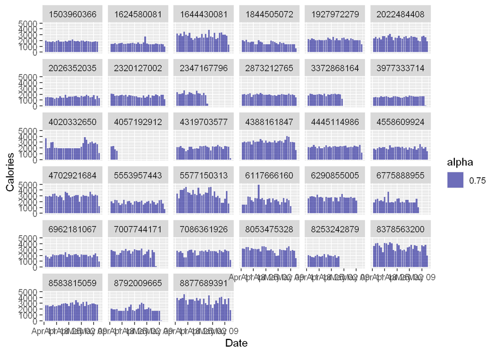

```r
ggplot(data = tbl_day_act, aes(x = Date, y = Calories, alpha = 0.75)) +
  geom_bar(stat = 'identity', fill='blue4') +
  facet_wrap(~ID)
```

**Outer joining the sleep & daily activity tables**

The tables could be inner joined but with an outer join, the option to filter out missing sleep data is there while still having access all of the data in the same dataframe.

```r
tbl_sleep$Datetime <- date(tbl_sleep$Datetime)
tbl_sleep <- rename(tbl_sleep, Date = Datetime)
act_sleep <- as_tibble(merge(x=tbl_day_act, y=tbl_sleep, by= c('Date', 'ID'), all=TRUE))
```

### **Investigating the effect of sleep on activity**

1. Filter out N/As in the sleep data.
2. Create a scatter plot of everyone’s total time asleep vs total distance.
3. Fit a line and correlate both variables.
4. What type of exercise does sleep correlate best to?

**Scatter plots w/line of best fit**

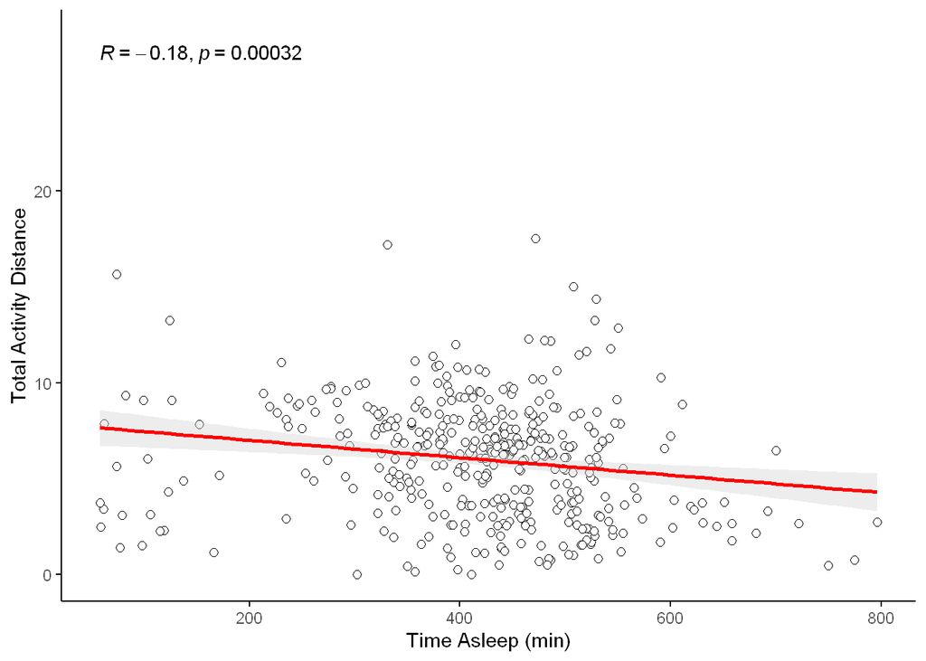

```r
ggscatter(act_sleep, x = "TotalMinutesAsleep", y = "TotalDistance",
          color = 'black', shape = 21, size = 2,
          add = "reg.line", conf.int = TRUE,
          add.params = list(color = 'red', fill = 'lightgrey'),
          cor.coef = TRUE, cor.method = "pearson",
          xlab = "Time Asleep (min)", ylab = "Total Activity Distance", ggtheme = theme_classic())
```

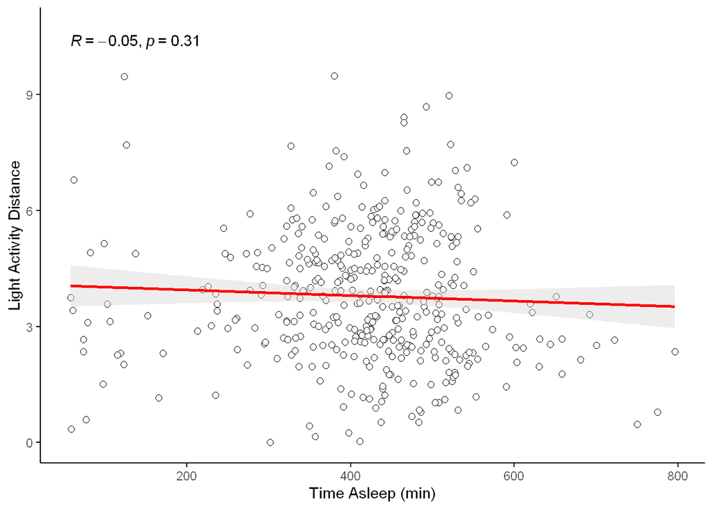

```r
ggscatter(act_sleep, x = "TotalMinutesAsleep", y = "LightActiveDistance",
          color = 'black', shape = 21, size = 2,
          add = "reg.line", conf.int = TRUE,
          add.params = list(color = 'red', fill = 'lightgrey'),
          cor.coef = TRUE, cor.method = "pearson",
          xlab = "Time Asleep (min)", ylab = "Light Activity Distance", ggtheme = theme_classic())
```

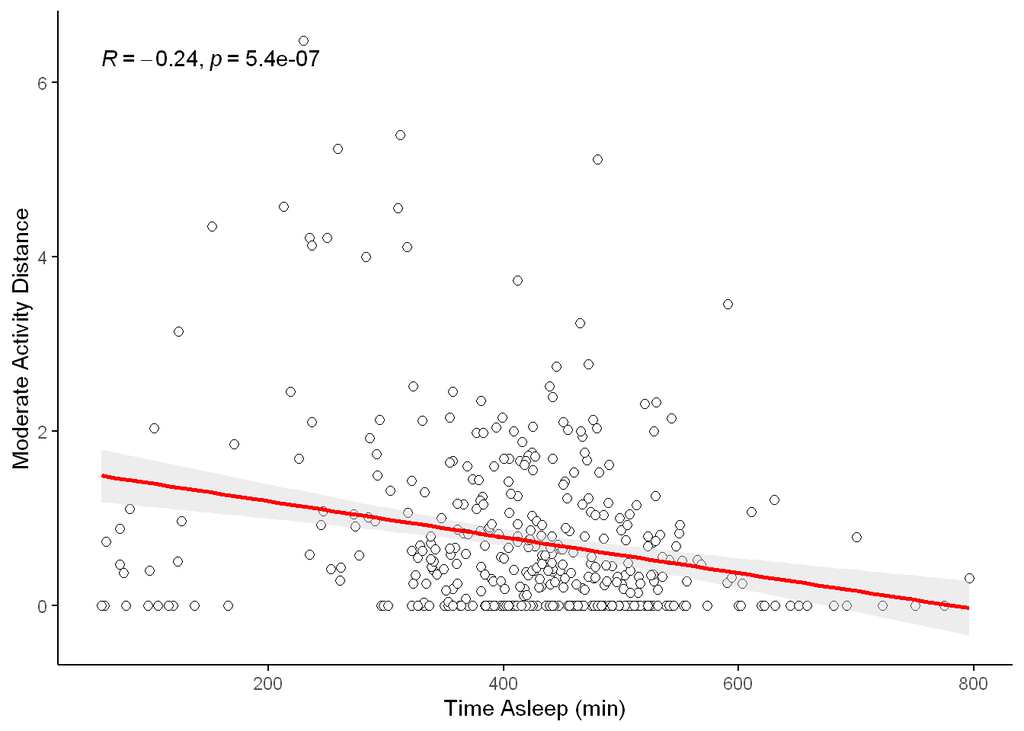

```r
ggscatter(act_sleep, x = "TotalMinutesAsleep", y = "ModeratelyActiveDistance",
          color = 'black', shape = 21, size = 2,
          add = "reg.line", conf.int = TRUE,
          add.params = list(color = 'red', fill = 'lightgrey'),
          cor.coef = TRUE, cor.method = "pearson",
          xlab = "Time Asleep (min)", ylab = "Moderate Activity Distance", ggtheme = theme_classic())
```

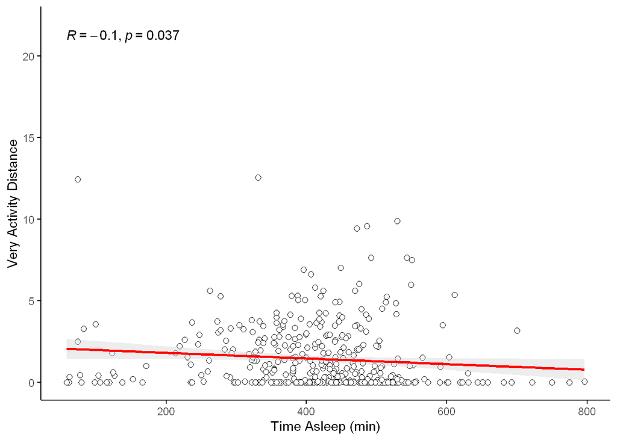

```r
ggscatter(act_sleep, x = "TotalMinutesAsleep", y = "VeryActiveDistance",
          color = 'black', shape = 21, size = 2,
          add = "reg.line", conf.int = TRUE,
          add.params = list(color = 'red', fill = 'lightgrey'),
          cor.coef = TRUE, cor.method = "pearson",
          xlab = "Time Asleep (min)", ylab = "Very Activity Distance", ggtheme = theme_classic())
```

All of the above are negatively correlated when using a line of best fit and the r value. This suggests that either less sleep is better for exercising more or that there is no relationship between the two.

**2D heat maps**

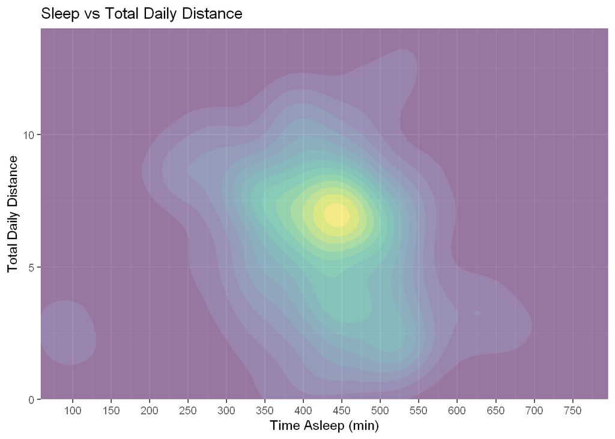

```r
ggplot(act_sleep, aes(TotalMinutesAsleep, round(TotalDistance, digits = 0))) +
  geom_density_2d_filled(show.legend = FALSE, alpha = 0.5) +
  coord_cartesian(expand = FALSE) +
  ylim(0, 14) +
  labs(title = 'Sleep vs Total Daily Distance', x = "Time Asleep (min)",
  y = "Total Daily Distance") +
  scale_x_continuous(breaks=seq(0, 800, 50))
```

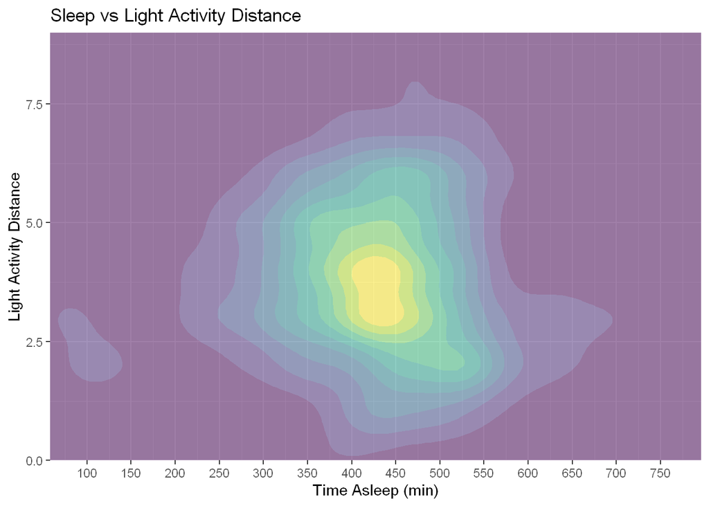

```r
ggplot(act_sleep, aes(TotalMinutesAsleep, round(LightActiveDistance, digits = 0))) +
  geom_density_2d_filled(show.legend = FALSE, alpha = 0.5) +
  coord_cartesian(expand = FALSE) +
  ylim(0, 9) +
  labs(title = 'Sleep vs Light Activity Distance', x = "Time Asleep (min)",
  y = "Light Activity Distance") +
  scale_x_continuous(breaks=seq(0, 800, 50))
```

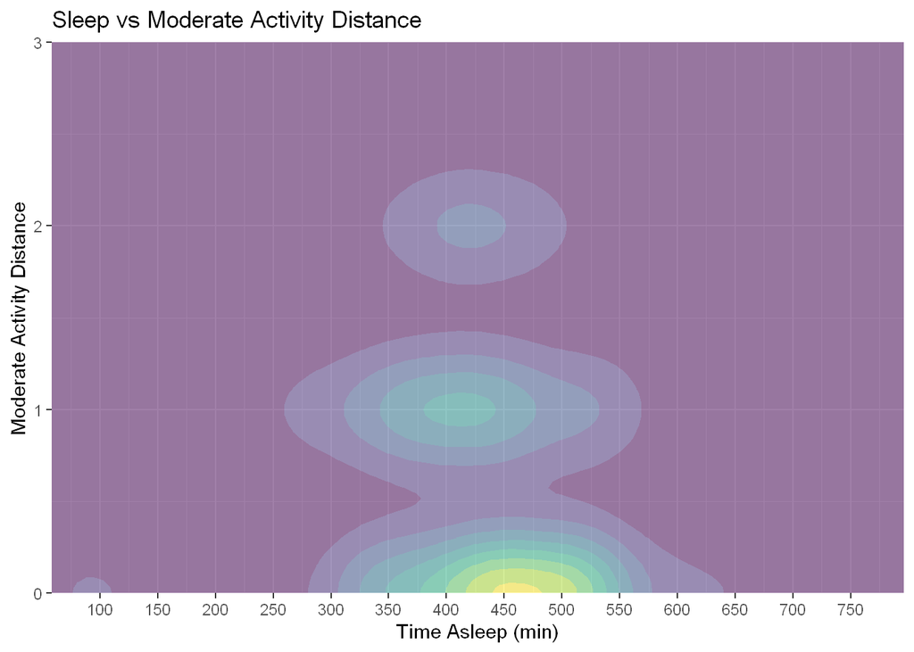

```r
ggplot(act_sleep, aes(TotalMinutesAsleep, round(ModeratelyActiveDistance, digits = 0))) +
  geom_density_2d_filled(show.legend = FALSE, alpha = 0.5) +
  coord_cartesian(expand = FALSE) +
    ylim(0, 3) +
  labs(title = 'Sleep vs Moderate Activity Distance',
  x = "Time Asleep (min)", y = "Moderate Activity Distance") +
  scale_x_continuous(breaks=seq(0, 800, 50))
```

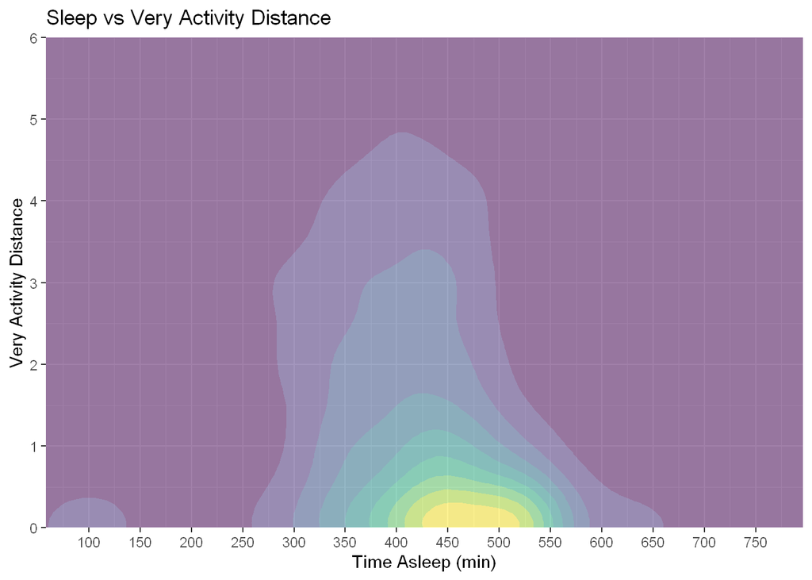

```r
ggplot(act_sleep, aes(TotalMinutesAsleep, round(VeryActiveDistance, digits = 0))) +
  geom_density_2d_filled(show.legend = FALSE, alpha = 0.5) +
  coord_cartesian(expand = FALSE) +
  ylim(0, 6) +
  labs(title = 'Sleep vs Very Activity Distance', x = "Time Asleep (min)",
  y = "Very Activity Distance") +
  scale_x_continuous(breaks=seq(0, 800, 50))
```

# Problems

- The Fitbit data used was collected from only 30 users. This is a very small sample size when considering that there are around 30 million users. Our sample size therefore represents roughly 1 millionth or 0.0001% of the population.
- In addition to the above, the data was collected in 2016 so it is outdated. Were this study carried out a year ago during a pandemic and lockdowns, the data might even be misleading as people’s exercise and eating habits are likely not the same during a pandemic.
- During the exploration of the dailyactivity table, 33 unique IDs were found. This is unexpected because it was stated that Fitbit data was collected from 30 users and yet there are 33 unique user IDs in the daily activity table.

# Discussion

1. **Daily Step Average** The average daily step count for our sample was roughly 7,500. This is below the recommended CDC goal for a daily average of 10,000 steps/day according to [this](https://www.cdc.gov/diabetes/prevention/pdf/postcurriculum_session8.pdf) document. This means our users are below the recommended daily count of 10,000 by 2,500 steps. However they exceed the US average of 3,000 - 4,000 by 3,500 - 4,500 steps.
2. **Time asleep vs activity**

There seems to be no positive correlation between sleep and activity or exercise, in fact there is an indication of a negative correlation. Which sounds counter intuitive.

All of the the scatter plots of sleep vs activity in the Exploratory Analysis section are negatively correlated when using a line of best fit and the r value. This suggests that either less sleep is better for exercising more or that there is no relationship between the two. The former is obviously wrong and the latter is most likely wrong too. Therefore this is not the appropriate way to interpret the data.

Looking at the scatter plots and where the points tend to accumulate, there seems to be a cluster of data points around the 420-450 minute mark. This suggests that there is not necessarily a linear relationship but rather an optimal x value to predict y values. This was graphically represented by a 2-D density heat map. From these density plots, the optimal sleep time for each activity type can be inferred

# Findings

1. **The average daily steps in this sample group was roughly 7,500**, this is 3,500-4,500 higher than the average American’s but 2,500 lower than the CDCs recommended daily amount .
2. Optimal amount of time sleeping for each acitivty type is as follows;
   - Light: Roughly 430 minutes or 7.2hrs
   - Moderate: Roughly 460 minutes or 7.7hrs
   - High: 450-500 mminutes or 7.5-8.3hrs
   - All of the above: Roughly 450 minutes or 7.5hrs

# Recommendations